# Finessing tissues’ spatial arrangement

Here we rearrange FOV’s by hand to make for plots with less white space. We’ll also append the metadata with further columns specifying tissue ID (which for multi-tissue slides is more granular than mere slide ID). For an under-development toolkit to automate this process, see [here](https://github.com/Nanostring-Biostats/CosMx-Analysis-Scratch-Space/blob/Main/blog/condensing%20FOVs%20and%20tissues%20in%20XY%20space.md).

### Preliminaries

First, we load in only the data we need:

```r
mydir <- ".."
metadata <- readRDS(paste0(mydir, "/processed_data/metadata_unfiltered.RDS")) # load cell metadata
```

Then break out cells’ xy positions in a distinct data object:

```r
xy <- as.matrix(metadata[, c("CenterX_global_px", "CenterY_global_px")])
rownames(xy) <- metadata$cell_id
# rescale to mm:
thisinstrument_nanometers_per_pixel = 120.280945
# The above value holds for most instruments. Your RunSummary file specifies the value for your instrument.
xy <- xy * thisinstrument_nanometers_per_pixel / 1000000
colnames(xy) <- paste0(c("x", "y"), "_mm")
```

Now we make sure that no tissue overlaps another. (In studies with multiple slides, xy positions can overlap.) The script utils/condenseTissues.R holds a useful function for automating this process:

```r
source("utils/condenseTissues.R")
set.seed(1)
xy <- condenseTissues(xy = xy,
                      tissue = metadata$Run_Tissue_name,
                      tissueorder = NULL,  # optional, specify the order tissues are tiled in
                      buffer = 1, # space between tissues
                      widthheightratio = 4/3) # desired shape of final xy locations
```

Now we can see our tissues’ xy coordinates:

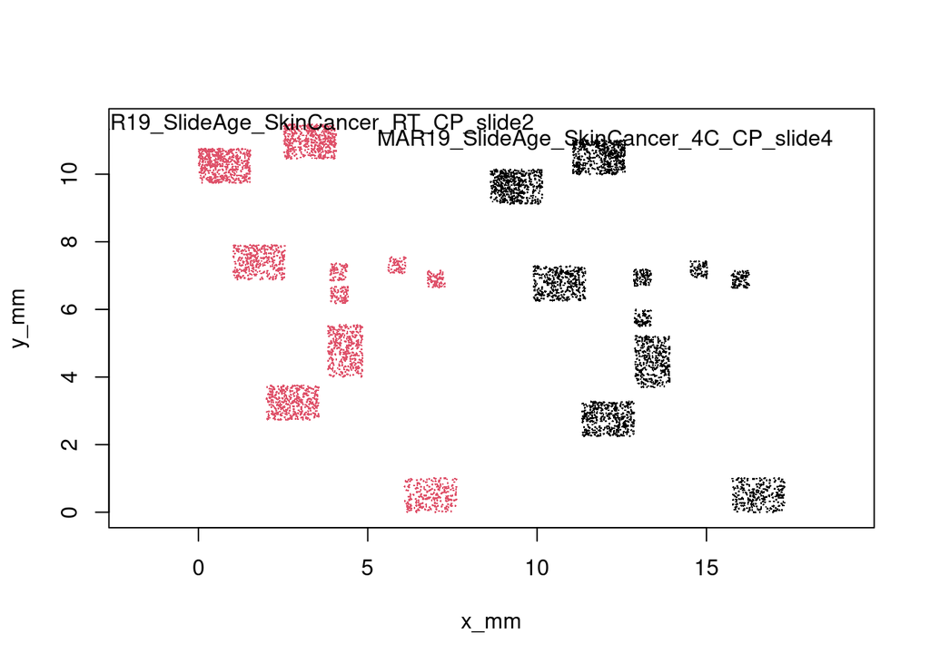

```r
# to avoid unnecessarily plotting all the cells, just show a subset:
sub <- sample(1:nrow(xy), round(nrow(xy) / 20), replace = FALSE)
# define a color palette (using a Google palette):
plot(xy[sub, ], pch = 16, cex = 0.2,
     asp = 1, # important: keep the true aspect ratio
     col = as.numeric(as.factor(metadata$Run_Tissue_name[sub])))
# label tissues:
for (slidename in unique(metadata$Run_Tissue_name)) {
  text(median(xy[metadata$Run_Tissue_name == slidename, 1]), max(xy[metadata$Run_Tissue_name == slidename, 2]), slidename)
}
```

### Custom labeling of tissues

```r
# manually assign tissue IDs:
# (Use whatever logic you need here. In this example, slide and tissue are synonymous, though they often won't be.)
metadata$tissue <- NA
metadata$tissue[(metadata$Run_Tissue_name == "MAR19_SlideAge_SkinCancer_RT_CP_slide2") & (xy[, 2] < 9)] <- "sample1"
metadata$tissue[(metadata$Run_Tissue_name == "MAR19_SlideAge_SkinCancer_RT_CP_slide2") & (xy[, 2] > 9)] <- "sample2"
metadata$tissue[(metadata$Run_Tissue_name == "MAR19_SlideAge_SkinCancer_4C_CP_slide4") & (xy[, 2] < 5.3)] <- "sample3"
metadata$tissue[(metadata$Run_Tissue_name == "MAR19_SlideAge_SkinCancer_4C_CP_slide4") & (xy[, 2] > 5.3)] <- "sample4"

# check for hiccups:
if (any(is.na(metadata$tissue))) {
  stop("some cells didn't get a tissue ID")
}
```

Now let’s see how our spatial plots look:

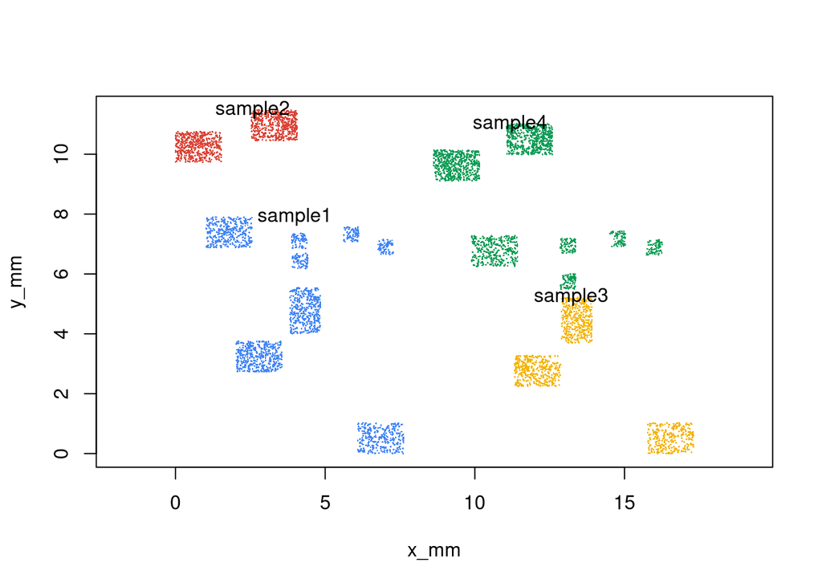

```r
# to avoid unnecessarily plotting all the cells, just show a subset:
sub <- sample(1:nrow(xy), round(nrow(xy) / 20), replace = FALSE)
# define a color palette (using a Google palette):
cols <- c("#616161","#4285f4","#db4437","#f4b400","#0f9d58","#ab47bc",
"#00acc1","#ff7043","#9e9d24","#5c6bc0","#f06292","#00796b","#c2185b","#7e57c2",
"#03a9f4","#8bc34a","#fdd835","#fb8c00","#8d6e63","#9e9e9e","#607d8b")
# plot:
plot(xy[sub, ], pch = 16, cex = 0.2,
     asp = 1, # important: keep the true aspect ratio
     col = cols[as.numeric(as.factor(metadata$tissue[sub])) %% length(cols) + 1])
# label tissues:
for (tiss in unique(metadata$tissue)) {
  text(median(xy[metadata$tissue == tiss, 1]), max(xy[metadata$tissue == tiss, 2]), tiss)
}
```

We can easily condense our tissues further. Let’s re-run the tissue condensing function using tissue ID instead of slide ID as we did previously:

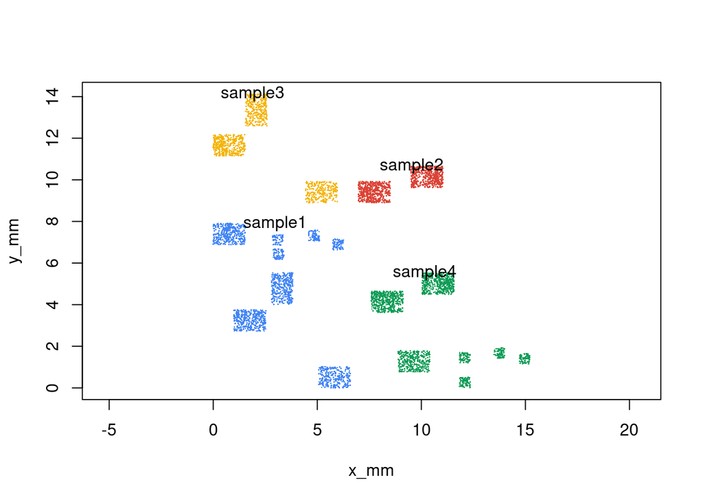

```r
# condense tissues:
set.seed(0)
xy <- condenseTissues(xy = xy,
                      tissue = metadata$tissue,
                      tissueorder = NULL,  # optional, specify the order tissues are tiled in
                      buffer = 1, # space between tissues
                      widthheightratio = 1) # desired shape of final xy locations
# now how do they look?
# to avoid unnecessarily plotting all the cells, just show a subset:
sub <- sample(1:nrow(xy), round(nrow(xy) / 20), replace = FALSE)
# define a color palette (using a Google palette):
cols <- c("#616161","#4285f4","#db4437","#f4b400","#0f9d58","#ab47bc",
"#00acc1","#ff7043","#9e9d24","#5c6bc0","#f06292","#00796b","#c2185b","#7e57c2",
"#03a9f4","#8bc34a","#fdd835","#fb8c00","#8d6e63","#9e9e9e","#607d8b")
# plot:
plot(xy[sub, ], pch = 16, cex = 0.2,
     asp = 1, # important: keep the true aspect ratio
     col = cols[as.numeric(as.factor(metadata$tissue[sub])) %% length(cols) + 1])
# label tissues:
for (tiss in unique(metadata$tissue)) {
  text(median(xy[metadata$tissue == tiss, 1]), max(xy[metadata$tissue == tiss, 2]), tiss)
}
```

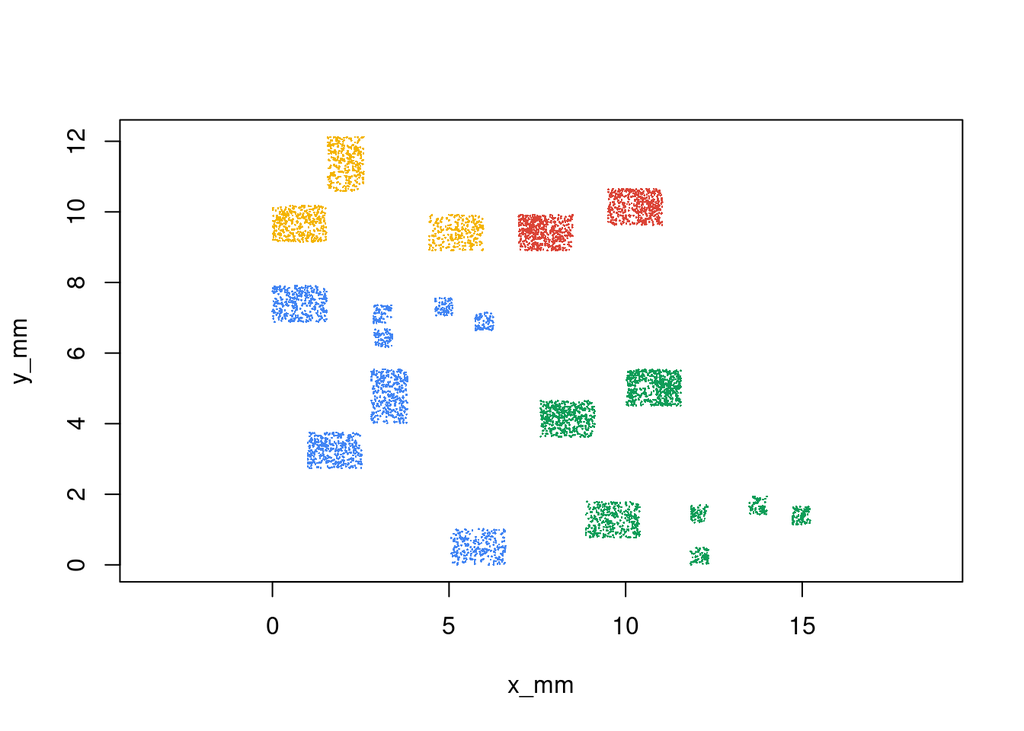

```r
isfarout <- (metadata$tissue == "sample3") & (xy[, 2] > 11)
xy[isfarout, 2] <- xy[isfarout, 2] - 2
sub <- sample(1:nrow(xy), round(nrow(xy) / 20), replace = FALSE)
plot(xy[sub, ], pch = 16, cex = 0.2,
     asp = 1, # important: keep the true aspect ratio
     col = cols[as.numeric(as.factor(metadata$tissue[sub])) %% length(cols) + 1])
```

Finally, we save our new coordinate system and move on to the next module.

```r
saveRDS(xy, file = paste0(mydir, "/processed_data/xy_unfiltered.RDS"))
saveRDS(metadata, file = paste0(mydir, "/processed_data/metadata_unfiltered.RDS"))
```